# 8. TURTLE (KAPLUMBAĞA) MODÜLÜ İLE GRAFİK ARAYÜZE GİRİŞ

Bu bölüm, bilgisayar ekranlarından aşina olduğunuz pencereler (formlar) ile tanışacağınız ve kullanmaya başlayacağınız kısımdır. Grafik arayüz (pencere) kavramı, temelde yazılımın komut satırından çıkıp görsel ara birimler aracılığıyla ifade edilmesidir. Kaplumbağa grafikler grafik arayüz üzerinde çizim araçları kullanarak çalışılmasına olanak tanırlar. Kaplumbağa grafikler Python gibi metin tabanlı dillerde kod yazmaya yeni başlayanlar için en eğlenceli modüllerden biridir. Kaplumbağa grafikler ile daha önceki bölümlerde öğrendiğiniz kavramları kullanarak bol miktarda pratik yapabilirsiniz. Kaplumbağa grafiklerin tarihine bakıldığında matematik eğitimi için logo programla dilinde kullanıldığı görülmektedir. John Dewey’in öğrencisi olan Seymour Papert, öğrencilerine matematik öğretmek için kaplumbağa robotunu geliştirmiştir

Turtle **(kaplumbağa)** standart python modüllerinden biridir. Bu nedenle turtle modülünü çalışmamızda kullanabilmek için modülü içeri aktarmamız (dâhil etmemiz) gerekmektedir. Bunun için ilk satıra **import turtle** yazmanız yeterli olacaktır. Python turtle modülünü çağırırken **turtle.py** adında bir dosya çağırdığından yapılacak örneklere turtle.py isminin verilmemesi yararlı olacaktır. turtle modülü projeye dâhil edildikten sonra bir turtle nesnesi oluşturup buna isim verilir. Bunu çizim yapmak için bir kalem almak gibi düşünebilirsiniz. **Bu bölümdeki uygulamalar idle kullanılarak yapılmıştır.**

## 8.1. Turtle (kaplumbağa) ile Çalışma

**Örnek 1**

**100 birimlik ileri yönde çizgi çizme**

```python
import turtle
kalem=turtle.Turtle()
kalem.forward(100)
turtle.done()
```

## 8.2. Temel Hareket İşlemleri

Turtle modülünde dört temel hareket bulunmaktadır. Bunlar, ileri: **forward (mesafe)**, geri: **backward (mesafe)**, sağ: **right (açı)**, sol: **left (açı)** komutlarıdır. Bu komutlar kullanılarak yapılan örnekleri inceleyelim.

**Örnek 2**

**right ve forward fonksiyonlarının birlikte kullanımı**

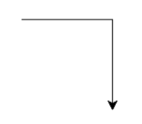

```python
import turtle
kalem=turtle.Turtle()
kalem.forward(100)
kalem.right(90)
kalem.forward(100)
turtle.done()
```

**Şekil 8.3:** Örnek 2 kod çıktısı

**Örnek 3**

**right ve backward fonksiyonlarının birlikte kullanımı**

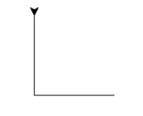

```python
import turtle
kalem=turtle.Turtle()
kalem.backward(100)
kalem.right(90)
kalem.backward(100)
turtle.done()
```

**Şekil 8.4:** Örnek 3 kod çıktısı

**Örnek 4**

**right ve forward fonksiyonlarının birlikte kullanımı**

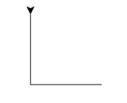

```python
import turtle
kalem=turtle.Turtle()
kalem.forward(-100.5)
kalem.right(90)
kalem.forward(-100.5)
turtle.done()
```

**Şekil 8.5:** Örnek 4 kod çıktısı

**Örnek 5**

**right ve backward fonksiyonlarının birlikte kullanımı**

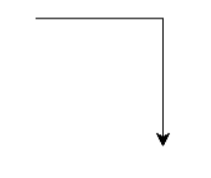

```python
import turtle
kalem=turtle.Turtle()
kalem.backward(-100.6)
kalem.right(90)
kalem.backward(-100.6)
turtle.done()
```

**Şekil 8.6:** Örnek 5 kod çıktısı

Şekil 8.3 ve Şekil 8.6 benzer çıktılar oluştuğunu fark ettiniz mi? Aynı durum Şekil 8.4 ve Şekil 8.5 için de geçerlidir. Bilgisayar: ileri 100 adım git ile geri eksi 100 adım git komutlarını aldığında aynı sonucu üretir. Kod çıktıları arasındaki fark mesafe girdileridir

**Örnek 6**

**left ve forward fonksiyonlarının birlikte kullanımı**

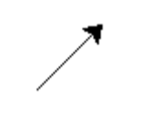

```python
import turtle
kalem=turtle.Turtle()
kalem.left(45)
kalem.forward(50)
turtle.done()
```

**Şekil 8.7:** Örnek 6 kod çıktısı

**Örnek 7**

**Açı kullanarak şekil çizme örneği**

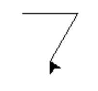

```python
import turtle
kalem=turtle.Turtle()
kalem.forward(50)
kalem.right(120)
kalem.forward(50)
kalem.right(120)
turtle.done()
```

**Şekil 8.8: Örnek 7 kod çıktısı**

Temel hareketler için bu örnekleri uyguladıktan sonra hareket fonksiyonlarının açı ve uzunlukları kullanıcıdan alacağınız örnekleri inceleyebilirsiniz

**HATIRLATMA**

```
Kullanıcıdan input(  ) fonksiyonu ile alınan metin değerini int veya float değerine dönüştürülmesi
gerekir aksi durumda hata mesajı karşılaşılır.
```

**Örnek 8**

**Çizgi mesafesini kullanıcıdan alıp şekil çizen program**

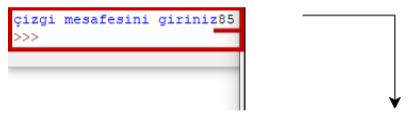

```python
import turtle
kalem=turtle.Turtle()
mesafe=float(input("çizgi mesafesini
giriniz"))
kalem.forward(mesafe)
kalem.right(90)
kalem.forward(mesafe)
turtle.done()
```

**Şekil 8.9:** Örnek 8 kod çıktısı

**Örnek 9**

**Çizgi mesafesini ve dönüş açısını kullanıcıdan alıp şekil çizen program**

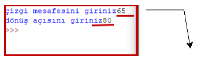

```python
import turtle
kalem=turtle.Turtle()
mesafe=int(input("çizgi mesafesini
giriniz"))
donus_açısı=int(input("dönüş açısını
giriniz"))
kalem.forward(mesafe)
kalem.right(donus_açısı)
kalem.forward(mesafe)
turtle.done()
```

**Şekil 8.10:** Örnek 9 kod çıktısı

## 8.3. İşaretçi ve Çizim Araçları

Turtle nesnesinde çizim için kalem rengi: **pencolor(” “)** veya **color(” ”)** girdi olarak iki tırnak içinde renk adı “red” veya tırnak içinde diyez ile birlikte html renk kodu “#ACE515” gibi alır. Renk kodlarını https://htmlcolorcodes.com/ adresinden öğrenebilirsiniz. Kalem kalınlığı** pensize (sayı değeri)** fonksiyonu ile ayarlanır

**Örnek 10**

**pencolor, pensize ve color uygulaması**

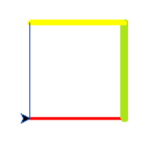

```python
import turtle
kalem=turtle.Turtle()
kalem.pencolor("red")
kalem.pensize(3)
kalem.forward(100)
kalem.left(90)
kalem.color("#ACE515")
kalem.pensize(8)
kalem.forward(100)
kalem.left(90)
kalem.pencolor("yellow")
kalem.pensize(6)
kalem.forward(100)
kalem.left(90)
kalem.color("#2259C1")
kalem.pensize(1)
kalem.forward(100)
kalem.left (90)
turtle.done()
```

**Şekil 8.11:** Örnek 10 kod çıktısı

Kaplumbağa grafiklerde pencerenin istenen noktasına gidebilme **goto (x ekseni, y ekseni)** Kaplumbağa grafiklerde nokta çizme **dot( )** Kaplumbağa grafiklerde çizmeden ilerleme **penup( )** veya **up( )** ardından **forward( )** Kaplumbağa grafiklerde çizime tekrar dönmek için ilerleme **pendown( )** veya **down( )** ardından **forward( )** fonksiyonları kullanılır. Turtle çizim aracının görünüm şekli için de **shape( )** fonksiyonu bulunmaktadır. Bu fonksiyon **‘arrow’, ‘classic’, ‘turtle’, ‘circle’** olmak üzere 4 şekle sahip olabilir.

**Örnek 11**

**dot ile çizim uygulaması**

```python
import turtle
kalem=turtle.Turtle()
for i in range(5):
 kalem.dot()
 kalem.forward(20)
turtle.done()
```

**örnek 12**

**dot ile çizgisiz şekil uygulaması**

```python
import turtle
kalem=turtle.Turtle()
kalem.up()
for i in range(5):
 kalem.dot()
 kalem.forward(20)
turtle.done()
```

**Örnek 13**

**shape ve goto fonksiyonlarının kullanımı**

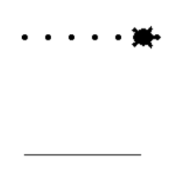

```python
import turtle
kalem=turtle.Turtle()
kalem.shape("turtle")
kalem.forward(100)
kalem.penup()
kalem.goto(0,100)
for i in range(5):
 kalem.dot()
 kalem.forward(20)
turtle.done()
```

**Şekil 8.14:** Örnek 13 kod çıktısı

**Örnek 14**

**shape ve goto fonksiyonlarının farklı bir çizim için kullanımı**

```python
import turtle
kalem=turtle.Turtle()
kalem.shape("turtle")
for i in range(4):
 kalem.up()
 kalem.forward(20)
 kalem.dot()
 kalem.down()
 kalem.forward(20)
 kalem.dot()
turtle.done()
```

## 8.4. Turtle ile Geometrik Şekiller Çizme

Turtle nesnesi ile geometrik şekiller çizmek oldukça kolaydır. Çokgenler başta olmak üzere birçok geometrik şekli ileri ve sağ/sol dönüş fonksiyonları ile yapmak mümkündür. Örnek 15’te bir kare çizdirildiğini fark etmişsinizdir. Fark etmenizi istediğimiz bir diğer nokta, forward ve left fonksiyonlarının 4 defa kullanılmasıdır (Örnek 15). Kodu defalarca yazmak yerine döngüler konusunda işlendiği gibi for yapısı ile kolayca çizdirebiliriz. Aynı mantığı Örnek 16’da gösterildiği gibi altıgen çizdirmek için kullanabiliriz.

**Örnek 15**

**turtle ile kare çizme uygulaması**

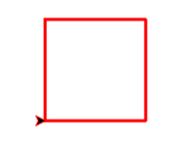

```python
import turtle
kalem=turtle.Turtle()
kalem.pencolor("red")
kalem.pensize(3)
for i in range(4):
 kalem.forward(100)
 kalem.left(90)
turtle.done()
```

**Şekil 8.16:** Örnek 15 kod çıktısı

**Örnek 16**

**turtle ile altıgen çizme uygulaması**

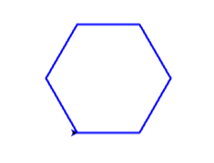

```python
import turtle
kalem=turtle.Turtle()
kalem.pencolor("blue")
kalem.pensize(3)
for i in range(6):
 kalem.forward(100)
 kalem.left(60)
turtle.done()
```

**Şekil 8.17:** Örnek 16 kod çıktısı

Çokgen çizdirmeyi kenar sayısını kullanıcıdan isteyerek de yapabilirsiniz. Burada dikkat edilecek nokta çokgen kaç kenarlı olursa olsun çokgen çizimi tamamlandığında 360 derecelik dönüş yapacak olmasıdır. Bu nedenle çokgenin dönüş açısı **360/ kenar** sayısı olur

**Örnek 17**

**Kullanıcının istediği kenar sayısında çokgen çizdirmek**

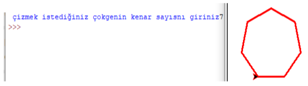

```python
import turtle
kalem=turtle.Turtle()
kalem.pencolor("red")
kalem.pensize(3)
kenar_sayısı=int(input(" çizmek istediğiniz çokgenin kenar sayısını giriniz"))
for i in range(kenar_sayısı):
 kalem.forward(50)
 kalem.left(360/kenar_sayısı)
turtle.done()
```

**Şekil 8.18:** Örnek 17 kod çıktısı

Çember çizmek için **circle (yarıçap değeri)** fonksiyonu yeterlidir. Örnek 18’de farklı renkte ve yarıçapta 3 adet çember çizdirilmektedir.

**Örnek 18**

**circle fonksiyonu ile 3 farklı yarıçapta ve renkte çember çizdirme**

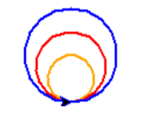

```python
import turtle
kalem=turtle.Turtle()
kalem.pencolor("orange")
kalem.pensize(2)
kalem.circle(20)
kalem.pencolor("red")
kalem.circle(30)
kalem.pencolor("blue")
kalem.circle(40)
turtle.done()
```

**Şekil 8.19:** Örnek 18 kod çıktısı

Çember ve çokgenler kullanılarak çok farklı desenler oluşturabileceğini fark ettiniz mi? Çokgenlerle farklı desenler oluşturmaya dair Örnek 19’u inceleyebilirsiniz. Bunu yapmak için iç içe döngüler kullanılmaktadır. Yani çokgenlerden bol miktarda çizdirilmesi gerekmektedir. Bu kodlar robota yaptırıldığında istenilen desenler farklı yüzeylere çizdirilebilirdi.

**Örnek 19**

**İç içe döngüler ile desen çizdirme**

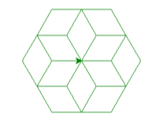

```python
import turtle
kalem=turtle.Turtle()
kalem.color("green")
for i in range (6):
 for j in range (6):
  kalem.forward(50)
  kalem.left(60) # iç döngü
 kalem.left(60)# dış döngü
turtle.done()
```

**Şekil 8.20:** Örnek 19 kod çıktıs

Örnek 19’daki deseni istendiğinde ve parametreler girildiğinde çizen bir fonksiyon tanımlayıp kullanınız.

Örnekte fonksiyon için verilen değerlerin doğruluğunun kontrol edildiğine dikkat ediniz. Kenar uzunluğunun eksi olarak da girilebileceği düşünüldüğünden ve if koşul yapısının karmaşık hâle getirilmemesi için dâhil edilmemiştir.

**Örnek 20**

**Desen çizen fonksiyon uygulaması**

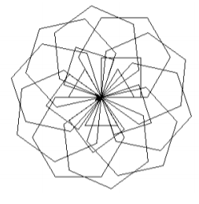

```python
import turtle
def desen_çiz (kenar_uzunluğu=50,iç_kenar=3,tur_sayısı=3):
 if(tur_sayısı <01 or iç_kenar<3):
  print("hatalı veri girdiniz")
 else:
  kalem=turtle.Turtle()
  for i in range (tur_sayısı):
   for j in range (iç_kenar):
    kalem.forward(kenar_uzunluğu)
    kalem.left(360/iç_kenar)
   kalem.left(360/tur_sayısı)
desen_çiz()
desen_çiz(60,4,5)
desen_çiz(70,6,10)
turtle.done()
```

**Şekil 8.21:** Örnek 20 kod çıktısı